# Acquire and Analyze - Applied Data Analytics

Claire Danicich

11/15/2020

```r
data_file <- "top2018.csv"
top <- read_csv(data_file)

knitr::kable(summary(top[4:14]))
```

|  | danceability | energy | key | loudness | mode | speechiness | acousticness | instrumentalness | liveness | valence | tempo |
| --- | --- | --- | --- | --- | --- | --- | --- | --- | --- | --- | --- |
|  | Min. :0.2580 | Min. :0.2960 | Min. : 0.00 | Min. :-10.109 | Min. :0.00 | Min. :0.02320 | Min. :0.000282 | Min. :0.000e+00 | Min. :0.02150 | Min. :0.0796 | Min. : 64.93 |
|  | 1st Qu.:0.6355 | 1st Qu.:0.5620 | 1st Qu.: 1.75 | 1st Qu.: -6.651 | 1st Qu.:0.00 | 1st Qu.:0.04535 | 1st Qu.:0.040225 | 1st Qu.:0.000e+00 | 1st Qu.:0.09467 | 1st Qu.:0.3410 | 1st Qu.: 95.73 |
|  | Median :0.7330 | Median :0.6780 | Median : 5.00 | Median : -5.566 | Median :1.00 | Median :0.07495 | Median :0.109000 | Median :0.000e+00 | Median :0.11850 | Median :0.4705 | Median :120.12 |
|  | Mean :0.7165 | Mean :0.6591 | Mean : 5.33 | Mean : -5.678 | Mean :0.59 | Mean :0.11557 | Mean :0.195701 | Mean :1.584e-03 | Mean :0.15830 | Mean :0.4844 | Mean :119.90 |
|  | 3rd Qu.:0.7983 | 3rd Qu.:0.7722 | 3rd Qu.: 8.25 | 3rd Qu.: -4.364 | 3rd Qu.:1.00 | 3rd Qu.:0.13700 | 3rd Qu.:0.247750 | 3rd Qu.:3.087e-05 | 3rd Qu.:0.17075 | 3rd Qu.:0.6415 | 3rd Qu.:140.02 |
|  | Max. :0.9640 | Max. :0.9090 | Max. :11.00 | Max. : -2.384 | Max. :1.00 | Max. :0.53000 | Max. :0.934000 | Max. :1.340e-01 | Max. :0.63600 | Max. :0.9310 | Max. :198.07 |

```
## # A tibble: 100 x 1
##    `top$artists`
##    <chr>
##  1 Drake
##  2 XXXTENTACION
##  3 Post Malone
##  4 Post Malone
##  5 Drake
##  6 Post Malone
##  7 Cardi B
##  8 Calvin Harris
##  9 Dua Lipa
## 10 Marshmello
## # … with 90 more rows
```

```
## # A tibble: 1 x 1
##       n
##   <int>
## 1    70
```

Below, I used the pairs.panels function to visualize correlations between the explanatory variables. The larger the numbers the stronger the relationship and visa versa. The only pair with a strong relationship is energy and loudness with .73.

```
## # A tibble: 5 x 16
##   id    name  artists danceability energy   key loudness  mode speechiness
##   <chr> <chr> <chr>          <dbl>  <dbl> <dbl>    <dbl> <dbl>       <dbl>
## 1 6DCZ… God'… Drake          0.754  0.449     7    -9.21     1      0.109
## 2 3ee8… SAD!  XXXTEN…        0.74   0.613     8    -4.88     1      0.145
## 3 0e7i… rock… Post M…        0.587  0.535     5    -6.09     0      0.0898
## 4 3swc… Psyc… Post M…        0.739  0.559     8    -8.01     1      0.117
## 5 2G7V… In M… Drake          0.835  0.626     1    -5.83     1      0.125
## # … with 7 more variables: acousticness <dbl>, instrumentalness <dbl>,
## #   liveness <dbl>, valence <dbl>, tempo <dbl>, duration_ms <dbl>,
## #   time_signature <dbl>
```

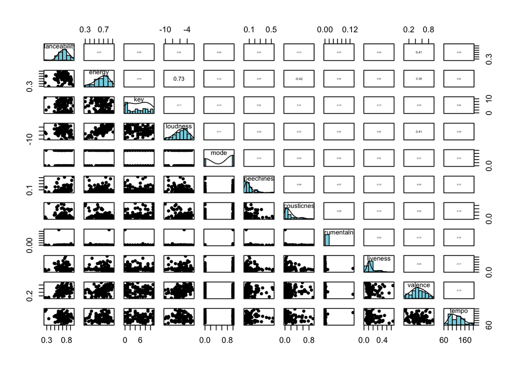

Below are table summaries of Loudness and Energy as per the panels they have the highest relationship. The next step in determining whether or not they are actually correlated by running a Pearson Correlation Test. For this test, our null hypothesis is that there is no linear correlation between Loudness and Energy and our alternative hypothesis is that there is a linear correlation between Loudness and Energy of the song. The correlation test will tell us if Loudness and Energy are associated and help explain the relationship between the two continuous variables. Below are summary tables of each varibale’s descriptive statistics.

Loudness

|  | min | Q1 | median | Q3 | max | mean | sd | n | missing |
| --- | --- | --- | --- | --- | --- | --- | --- | --- | --- |
|  | -10.109 | -6.6505 | -5.5665 | -4.36375 | -2.384 | -5.67764 | 1.777577 | 100 | 0 |

Energy

|  | min | Q1 | median | Q3 | max | mean | sd | n | missing |
| --- | --- | --- | --- | --- | --- | --- | --- | --- | --- |
|  | 0.296 | 0.562 | 0.678 | 0.77225 | 0.909 | 0.65906 | 0.1450672 | 100 | 0 |

With 95% confidence and a p-value of less than .001, we can reject the null hypothesis and accept the alternative hypothesis that there is a linear realtionship between loudness and energy (t = 10.659, df = 98, p-value < 2.2e-16). With a correlation value of .733, there is a strong correlation between loudness and energy.

```r
res1 <- cor.test(top$loudness, top$energy,
                    method = "pearson")
res1
```

```
##
##  Pearson's product-moment correlation
##
## data:  x and y
## t = 10.659, df = 98, p-value < 2.2e-16
## alternative hypothesis: true correlation is not equal to 0
## 95 percent confidence interval:
##  0.6264607 0.8122401
## sample estimates:
##       cor
## 0.7327191
```

The following plots the linearity of Energy and Loudness. Here you can see the linear relationship between the two variables. The regression line is included in black and the smoothed, fitted regression line is in blue. The upper left hand corner also includes the correlation coefficient.

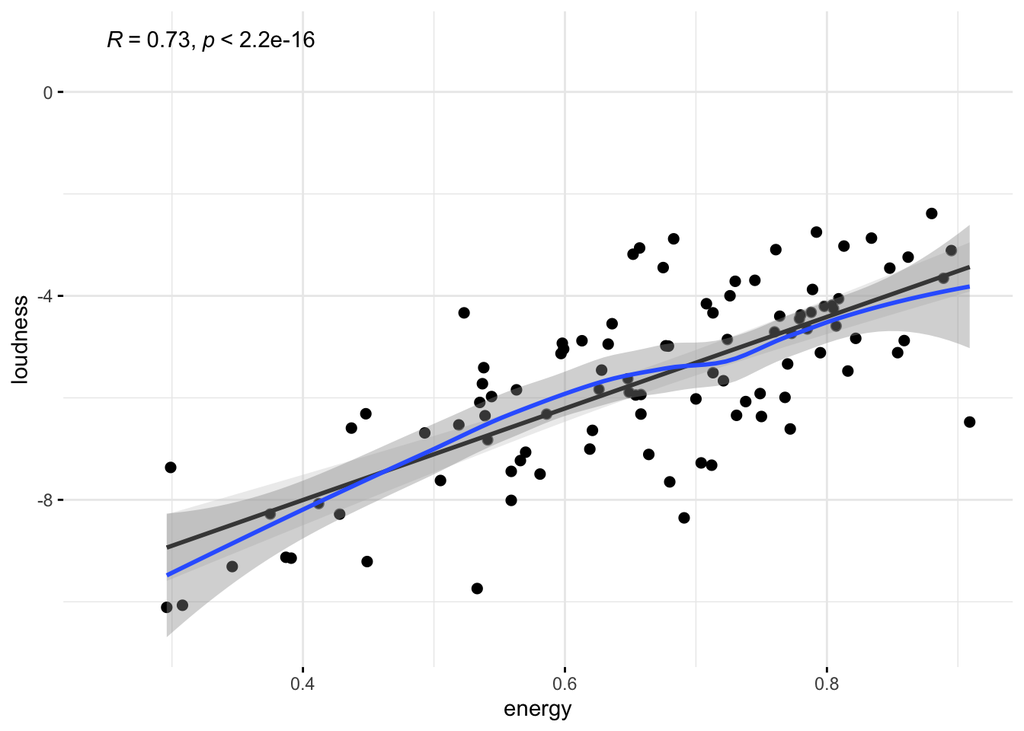

Not knowing anything about musical variables, I believe it makes sense that these two variables are correlated. I found it interesting that there were little to no reltaionships elsewhere in the pairs.panels. My next question would be to determine what makes a song hit the top 100 charts - is it the danceibility, the liveness, the energy? Or is it that certain artists are just more likely to make the list because of their popularity?